# Brown bear abundance

[NO_BBAB_001]

Author

Affiliation

Aud H. Halbritter

University of Bergen

Published

May 15, 2026

> **Recommended citation**: Halbritter, A. H. 2026. Brown bear abundance [Brunbjørnbestand] (ID(s): NO_BBAB_001) v. 0.1.0. ecRxiv: https://github.com/NINAnor/ecRxiv/tree/main/indicators/NO_BBAB_001

**TipMetadata**

Table 1: Indicator metadata

| Variable | Value |
| --- | --- |
| Indicator ID | NO_BBAB_001 |
| Indicator Name | Brown bear abundance [Brunbjørnbestand] |
| Country | Norway |
| Continent | Europe |
| Ecosystem Condition Typology Class | B3 Functional state characteristics |
| Realm | Terrestrial (T) |
| Biome | T2 Temperate-boreal forests and woodlands biome |
| Ecosystem | T2.1 Boreal/montane forests |
| Year added | 2026 |
| Last update | 2026 |
| Version | 0.1.0 |
| Version comment | First version on ecRxiv, but this indicator is already published and described in the Norwegian Nature Index |
| Normalised | TRUE |
| Spatial aggregation pathway | Aggregate (population model, large-carnivore management region) - [Scale - Truncate] - Aggregate (national level) |

**TipLog**

- May 15, 2026 - Original PR

## 1.2 Native language summary - Norwegian

1. **Bakgrunn og begrunnelse**: Brunbjørn (*Ursus arctos*) er et stort, altetende pattedyr som finnes i skog- og fjellområder i Norge, særlig i øst, Trøndelag og nord. Som rovdyr og åtseleter har arten en viktig funksjon i boreale og fjellnære skogøkosystemer. Bestandsutviklingen speiler habitatkvalitet, sammenheng i landskapet og menneskelig påvirkning, blant annet tap og fragmentering av habitat, trafikkdødelighet, skadeforvaltning og lisensjakt. Norge har langvarig, DNA-basert overvåking av brunbjørn (Brøseth, Kopatz, and Kleven 2024), som gir et relativt godt grunnlag for å bruke arten som indikator på økologisk tilstand. Indikatoren inngår i Naturindeksen og er beskrevet på [Naturindeksen](https://naturindeks.no/Indicators/brunbjoern).
2. **Metoder**: Estimert brunbjørnbestand (eller et tilsvarende bestandsindeks) bygger på det nasjonale DNA-overvåkingsprogrammet og tilhørende statistiske modeller, ikke på jaktstatistikk. Genetisk materiale (ekskrement, hår m.m.) brukes til å identifisere individer; bestandsstørrelse rapporteres for forvaltningsregioner for rovvilt. Verdiene normaliseres til en indikatorskala 0–1 med referanseverdier (*X<sub>100</sub>*) knyttet til disse regionene, og *X<sub>0</sub>* som verste tilstand. For Naturindeks aggregeres skalerte verdier videre til fem geografiske regioner og nasjonalt med arealvekter.
3. **Tolkning**: En indikatorverdi på 1 betyr at brunbjørnbestanden i rapporteringsenheten er minst like stor som forventet under referansetilstanden. Verdier som nærmer seg null, viser at bestandsindekset ligger lenger under referansen og at tilstanden har utviklet seg negativt i forhold til referansen.
4. **Resultater og utviklingsbehov**: Indikatoren er operativ i Naturindeksen.

## 2. About the underlying data

The primary data source for this indicator is the national programme for DNA-based monitoring of brown bears in Norway, coordinated under the large carnivore monitoring framework and reported annually (e.g. (Brøseth, Kopatz, and Kleven 2024)). For Naturindeks reporting, prepared indicator objects (population estimates or indices with uncertainty, plus reference values) are obtained from the Naturindeks database or equivalent exports.

### 2.1 Spatial and temporal resolution and extent

Indicator values are available for the assessment years in *Naturindeksen*: 1990, 2000, 2010, 2014, 2019, and 2024. To produce indicator estimates for these years, input from the DNA-monitoring programme is combined over a short window (typically two to three years), as specified in the Naturindeks indicator protocol.

### 2.2 Sampling design

Monitoring relies on opportunistic and targeted collection of DNA samples from the field (hunters, managers, researchers, and the public), followed by genetic analysis to assign samples to individuals and sexes. Coverage is extensive but not a classical random plot design: detection depends on sample submission, field effort, and bear presence. The method is designed for capture–recapture–style inference on identified individuals rather than complete census. Biases can arise from uneven sampling intensity between areas and years, misidentified samples, and incomplete detection of individuals. Full methodological detail is given on [Naturindeksen](https://naturindeks.no/Indicators/brunbjoern) and in the annual monitoring reports (Brøseth, Kopatz, and Kleven 2024).

### 2.3 Original units

At the monitoring stage, the core quantities are numbers of genetically identified individuals (and derived abundance or density estimates) from DNA profiles, reported nationally and by forvaltningsregion for rovvilt. For Naturindeks, these are translated into indicator variables (expected values with uncertainty distributions) stored in the NI database before normalisation to 0–1.

### 2.4 Instructions for citing, using and accessing data

Raw genetic monitoring results and annual reports should be cited from the NINA monitoring publications (e.g. (Brøseth, Kopatz, and Kleven 2024)). Methodological documentation for this species is linked from [Naturindeksen – brunbjørn](https://naturindeks.no/Indicators/brunbjoern).

## 3. Indicator properties

### 3.1 Ecosystem Condition Typology Class (ECT)

B3 – Functional state characteristics. Brown bear is assigned to functional composition because population status reflects the presence and role of a large carnivore in the ecosystem (trophic regulation, carcass subsidy, and related ecological processes), not only the occurrence of a single species name in a species list.

### 3.2 Ecosystem condition characteristic

The ecosystem characteristic represented is a functionally intact large-carnivore component of boreal and montane forest ecosystems: an ecosystem where brown bear occurs at abundances consistent with the reference condition and can fulfil its ecological roles without being depressed far below sustainable levels.

### 3.3 Collinearities with other indicators

The indicator may covary with other large carnivore or mammal indicators in the same regions (e.g. wolf, wolverine, lynx) and with indicators linked to similar forest and mountain habitats. Including several tightly correlated predator indicators in the same composite index without accounting for dependence could overweight the predator guild signal.

### 3.4 Impact factors

Important anthropogenic pressures include habitat alteration and fragmentation, infrastructure and traffic mortality, human–wildlife conflict and removals, licensed hunting and management actions, and climate-related changes affecting food resources and denning. Natural variation in reproduction and survival also affects the population index.

### 3.5 Spatial aggregation

Following the metadata pathway Aggregate (population model, large-carnivore management region) – [Scale – Truncate] – Aggregate (national level): population estimates or indices from the monitoring/model workflow are available per forvaltningsregion for rovvilt (IC unit in Naturindeksen). Each unit is normalised against *X<sub>0</sub>* and *X<sub>100</sub>* for that region (linear scaling with truncation to [0, 1]).

Regional (east, south, west, central, north) and national indicator values are then obtained as area-weighted combinations of the scaled management-region values, using weights from the Naturindeks spatial framework.

## 4. Reference condition and levels

### 4.1 Reference condition

The reference condition for brown bear in Naturindeksen is a boreal/montane forest ecosystem with minimal human impact and a climate similar to the reference period used in the Norwegian Nature Index framework (Nybø et al. 2017).

### 4.2 Reference levels

*X<sub>100</sub>* is set per large-carnivore management region (IC unit in Naturindeksen), using suitable area and density within each *rovviltregion* and expert assessment: it represents the expected brown bear population (or equivalent index) under reference conditions in that unit.

*X<sub>0</sub>* is defined as no brown bears in the unit (functional absence).

#### 4.2.1 Spatial resolution and validity

Reference levels and indicator values apply at the scale of forvaltningsregioner for rovvilt (IC units). Aggregated results for the five Naturindeks geographic regions and for Norway are summaries of those units with area weights.

## 5. Uncertainties

### 5.1 General uncertainties

Reference levels are held fixed in this workflow (their own uncertainties are not propagated). Regional and national values are area-weighted summaries of forvaltningsregioner for rovvilt, so they inherit model uncertainty at management-region scale and any mismatch between administrative regions and ecological variation within the five Naturindeks geographic regions. Monitoring design and sample effort differ between species and regions; uneven coverage can affect the population models that enter Naturindeksen.

### 5.2 Reported uncertainties

The intervals in Table 2 and Figure 2 are inferential: they describe uncertainty around the estimated area-weighted mean indicator for each reporting unit (a geographic region or Norway as a whole), given the statistical models used for management-region abundance in Naturindeksen.

## 6. References

Brøseth, Henrik, Alex Kopatz, and Odd Kleven. 2024. “DNA-Based Monitoring of Brown Bear in Norway in 2023.” 2454. Trondheim: Norwegian Institute for Nature Research (NINA). https://brage.nina.no/nina-xmlui/handle/11250/3124665.

Norwegian Institute for Nature Research, and partners. 2025. “Norwegian Nature Index (Naturindeks).” https://www.naturindeks.no.

Nybø, Signe et al. 2017. “Fagsystem for Naturindeks: Referansetilstand Og Skalering.” Norwegian Institute for Nature Research (NINA).

## 7. Import and prepare datasets

Run the download chunk once to refresh the local export. This project’s renv environment installs `NIcalc` from GitHub `ChloeRN/NIcalc`, branch `include_ReadOnly_access` (see `renv.lock` and `install_deps.R`); that build defaults to the Naturindeks read-only API user, so you do not need `username` / `password` arguments here. When [NINAnor/NIcalc PR #59](https://github.com/NINAnor/NIcalc/pull/59) is merged into `NINAnor/NIcalc`, you can switch the renv install back to the main repo and update the lockfile. We save the RDS export under `data/` so that we do not need to download the data every time we run the analysis.

**Download brown bear data from Naturindeks API**

```r
bbabImport <- NIcalc::importDatasetApi(
  eco = NULL,
  indic = c("Brunbjørn"),
  year = c("1990", "2000", "2010", "2014", "2019", "2024")
)

saveRDS(bbabImport, here::here("data/bbabImport.rds"))
```

## 8. Spatial units

The eight forvaltningsregioner for rovvilt (rovvilt regions 1–8) are the IC units in Naturindeks for this indicator. The five Naturindeks geographic regions (east, south, west, central, north; codes E, S, W, C, N) are taken from the `part` field on municipality-level `BSunits` in the same import, aggregated up to each management region (see Section 9). Mainland Norway is the ecosystem accounting area.

## 9. Analyses

This section takes variable values and reference levels from the Naturindeks import, normalises at management-region scale with linear scaling, then propagates uncertainty and aggregates spatially with terrestrial area weights. At geographic-region and national scale, uncertainties are inferential: each replicate is an area-weighted mean based on one draw per management region (then per geographic region), not a random draw from a pooled mixture of regions.

Management-region population indices in the database are stored as predictive distributions, not only as point estimates. Reference levels per region (*X<sub>0</sub>* = 0, *X<sub>100</sub>* from the download) are applied before any geographic or national aggregation. We ignore uncertainty in the reference levels themselves.

### Assemble import and indicator object

`assembleNiObject()` reshapes `bbabImport` so that indicator observations are in one list element per assessment year, and so that underlying spatial units (`BSunits`) are aligned with the thematic index structure used in Naturindeks.

**Assemble brown bear NI object (thematic, predefined regions)**

```r
bbabAssemble <- NIcalc::assembleNiObject(
  inputData = bbabImport,
  predefNIunits = c(allArea = T, parts = T, counties = F),
  indexType = "thematic"
)
```

```
Check input data .....
```

```
Elicitate incomplete reference values and indicator observations .....
```

```
Assemble dataset .....
```

### Reference levels (X<sub>0</sub> and X<sub>100</sub>)

Before scaling, we read regional reference levels from `referenceValues` in the RDS export (rows with `yearId == 0` or reference year name). For this indicator, *X<sub>0</sub>* is zero individuals in the unit and *X<sub>100</sub>* is the expert reference population index per rovvilt region (`expectedValue` in the reference slice).

**Management-region reference levels from downloaded Naturindeks data**

```r
refs <- bbabImport$referenceValues$referenceValues |>
  dplyr::filter(.data$yearId == 0L | grepl("Referanse", .data$yearName, fixed = FALSE)) |>
  dplyr::distinct(ICunitId, ICunitName, x100 = expectedValue) |>
  dplyr::mutate(x0 = 0)
refs |>
  gt::gt()
```

| ICunitId | ICunitName | x100 | x0 |
| --- | --- | --- | --- |
| 14827 | Rovviltregion 8 | 1492 | 0 |
| 14828 | Rovviltregion 7 | 758 | 0 |
| 14829 | Rovviltregion 6 | 1100 | 0 |
| 14830 | Rovviltregion 5 | 532 | 0 |
| 14831 | Rovviltregion 4 | 115 | 0 |
| 14832 | Rovviltregion 3 | 490 | 0 |
| 14833 | Rovviltregion 2 | 765 | 0 |
| 14834 | Rovviltregion 1 | 947 | 0 |

### Resample non-scaled management-region variables

For each assessment year, Naturindeks stores one value per rovvilt region as a parameterised distribution (or a custom distribution). We draw `nsim = 1000` random values per region with `NIcalc::sampleObsMat()`. Rows with a standard distribution family use observation type `tradObs`; rows with only a custom distribution use `customObs`.

Assessment years are 1990, 2000, 2010, 2014, 2019, and 2024. The result `dat` is a long table of simulated population indices (`value`) by `ICunitId` and `year`, not yet on the 0–1 indicator scale.

**Observation types for sampleObsMat**

```r
myYears <- as.character(c(1990, 2000, 2010, 2014, 2019, 2024))
obstype <- vector("list", length(myYears))
for (i in seq_along(myYears)) {
  obs <- bbabAssemble$indicatorValues[[i]]$distributionFamilyName
  obs[!is.na(obs)] <- "tradObs"
  obs[is.na(obs)] <- "customObs"
  obstype[[i]] <- obs
}
```

**Resample management-region variables (non-scaled)**

```r
dat <- tibble(ICunitId = NULL, value = NULL, year = NULL)

for (i in seq_along(myYears)) {
  myMat <- NIcalc::sampleObsMat(
    ICunitId = bbabAssemble$indicatorValues[[i]]$ICunitId,
    value = bbabAssemble$indicatorValues[[i]]$expectedValue,
    distrib = bbabAssemble$indicatorValues[[i]]$distributionFamilyName,
    mu = bbabAssemble$indicatorValues[[i]]$distParameter1,
    sig = bbabAssemble$indicatorValues[[i]]$distParameter2,
    customDistribution = bbabAssemble$indicatorValues[[i]]$customDistribution,
    obsType = obstype[[i]],
    nsim = 1000
  )
  ICunitIds <- row.names(myMat)
  colnames(myMat) <- paste0("s", seq_len(ncol(myMat)))
  myMat <- myMat |>
    as_tibble() |>
    add_column(ICunitId = ICunitIds, .before = 1) |>
    pivot_longer(cols = -any_of("ICunitId"), names_to = "sim_col", values_to = "value") |>
    mutate(
      sim_id = readr::parse_number(.data$sim_col),
      year = myYears[i]
    ) |>
    select(ICunitId, sim_id, value, year)

  dat <- dat |>
    bind_rows(myMat)
}
head(dat) |>
  gt::gt()
```

| ICunitId | sim_id | value | year |
| --- | --- | --- | --- |
| 14827 | 1 | 17.298841 | 1990 |
| 14827 | 2 | 12.454205 | 1990 |
| 14827 | 3 | 14.504211 | 1990 |
| 14827 | 4 | 17.468123 | 1990 |
| 14827 | 5 | 5.904049 | 1990 |
| 14827 | 6 | 12.963020 | 1990 |

### Scaling to indicator values (linear)

Normalisation is done at management-region scale before any geographic or national aggregation. Each draw is joined to its regional `x0` and `x100`, then mapped to `[0, 1]` with `ecTools::ec_normalise()` using linear increasing scaling from *X<sub>0</sub>* to *X<sub>100</sub>* (no upper-tail unimodal anchor).

**Join reference levels and linear scaling to indicator scale**

```r
dat <- dat |>
  left_join(
    refs |> mutate(ICunitId = as.character(ICunitId)),
    by = join_by(ICunitId)
  )

ind <- ec_normalise(
  variable = dat$value,
  x0 = dat$x0,
  x100 = dat$x100,
  fun = "linear"
)

dat <- dat |> add_column(indicator = ind)
```

The scatter plot below (Figure 1) shows the mapping from variable to indicator for each rovvilt region (one facet per `ICunitName`). The figure is saved when the document is rendered.

**Save normalisation diagnostic figure (English)**

```r
bear_plot <- ec_norm_plot(dat$value, dat$indicator) +
  facet_wrap(. ~ dat$ICunitName)
ggsave(filename = here::here("img/bbab_norm_plot_eng.png"), plot = bear_plot, scale = 1.5)
```

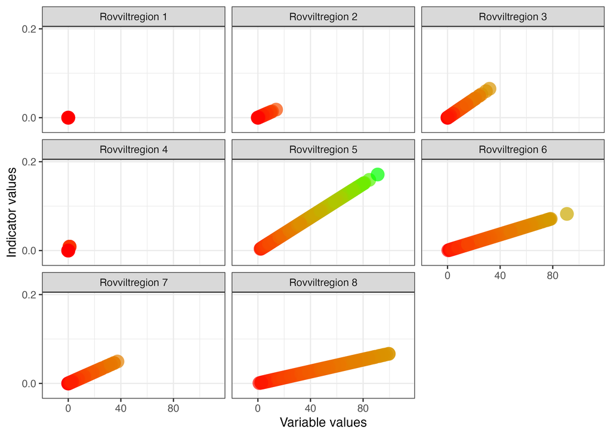

Figure 1: Linear normalisation of brown bear population index to indicator values (one panel per management region).

```r
knitr::include_graphics(here::here("img/bbab_norm_plot_eng.png"))
```

### Aggregation weights (terrestrial area by management region)

Spatial aggregation uses terrestrial area on each underlying spatial unit in `BSunits`, summed to management region (`ICunitId`). Municipalities are linked to rovvilt regions via `ICunits`, as for counties in the cervid indicators. Each `BSunit` carries a Naturindeks geographic region code (`part`: E, S, W, C, N). We sum terrestrial area by management region and by `part`, assign each management region to the `part` with the largest area share, and use total terrestrial area per management region as the weight in geographic and national means.

**Terrestrial area and NI part from BSunits in the import**

```r
aux <- as_tibble(bbabAssemble$BSunits) |>
  rename(BSunitId = id)

IC_BC_link <- bbabImport$ICunits |>
  distinct(ICunitId = as.character(id), BSunitId)

aux <- aux |>
  left_join(IC_BC_link, by = join_by(BSunitId))

ic_names <- bbabAssemble$indicatorValues[[1]] |>
  transmute(ICunitId = as.character(ICunitId), ICunitName)

part_from_data <- aux |>
  group_by(ICunitId, part) |>
  summarise(area_in_part = sum(terrestrialArea), .groups = "drop") |>
  group_by(ICunitId) |>
  slice_max(area_in_part, n = 1, with_ties = FALSE) |>
  select(ICunitId, part)

aux <- aux |>
  group_by(ICunitId) |>
  summarise(area_weight = sum(terrestrialArea), .groups = "drop") |>
  left_join(part_from_data, by = join_by(ICunitId)) |>
  left_join(ic_names, by = join_by(ICunitId))

dat <- dat |>
  left_join(aux, by = join_by(ICunitId))
```

### Aggregate to geographic regions (inferential uncertainty)

For each Monte Carlo replicate (b = 1, , 1000) and each geographic region–year, we draw one posterior sample per management region in that area (from that region’s 1000 simulations in `dat`), then compute the terrestrial-area-weighted mean across regions. The resulting 1000 values describe uncertainty around the geographic mean indicator.

**Bootstrap distribution of area-weighted geographic means**

```r
regions <- c("N", "C", "W", "S", "E")
B <- 1000L

out <- tibble(id = seq_len(B))

for (i in regions) {
  for (n in myYears) {
    d_yr <- dat |>
      filter(.data$part == i, .data$year == n)

    mgmt_regions <- sort(unique(d_yr$ICunitId))
    w <- aux |>
      filter(.data$ICunitId %in% mgmt_regions) |>
      arrange(match(.data$ICunitId, mgmt_regions))

    by_region <- split(d_yr$indicator, d_yr$ICunitId)[mgmt_regions]

    col_vals <- vapply(
      seq_len(B),
      function(b) {
        draws <- vapply(by_region, sample, numeric(1), size = 1L)
        stats::weighted.mean(draws, w$area_weight, na.rm = TRUE)
      },
      numeric(1)
    )

    out <- out |>
      add_column(!!paste(i, n, sep = "_") := col_vals)
  }
}
head(out)
```

```
# A tibble: 6 × 31
     id  N_1990 N_2000 N_2010 N_2014 N_2019 N_2024  C_1990 C_2000 C_2010 C_2014
  <int>   <dbl>  <dbl>  <dbl>  <dbl>  <dbl>  <dbl>   <dbl>  <dbl>  <dbl>  <dbl>
1     1 0.00969 0.0180 0.0364 0.0258 0.0236 0.0379 0.00525 0.0209 0.0430 0.0253
2     2 0.00846 0.0101 0.0237 0.0225 0.0256 0.0370 0.00516 0.0148 0.0338 0.0287
3     3 0.00621 0.0134 0.0203 0.0300 0.0239 0.0187 0.00554 0.0171 0.0417 0.0292
4     4 0.00465 0.0171 0.0176 0.0257 0.0248 0.0124 0.00514 0.0231 0.0391 0.0296
5     5 0.00777 0.0133 0.0211 0.0242 0.0218 0.0306 0.00473 0.0165 0.0324 0.0325
6     6 0.00526 0.0107 0.0290 0.0276 0.0237 0.0229 0.00389 0.0190 0.0414 0.0352
# ℹ 20 more variables: C_2019 <dbl>, C_2024 <dbl>, W_1990 <dbl>, W_2000 <dbl>,
#   W_2010 <dbl>, W_2014 <dbl>, W_2019 <dbl>, W_2024 <dbl>, S_1990 <dbl>,
#   S_2000 <dbl>, S_2010 <dbl>, S_2014 <dbl>, S_2019 <dbl>, S_2024 <dbl>,
#   E_1990 <dbl>, E_2000 <dbl>, E_2010 <dbl>, E_2014 <dbl>, E_2019 <dbl>,
#   E_2024 <dbl>
```

### Aggregate to national level (inferential uncertainty)

For each year and replicate (b), the national value is the terrestrial-area-weighted mean of the five geographic regional values from that same replicate (`aux2` gives total area per geographic region). This propagates uncertainty to the national mean in the same way as at geographic scale.

**Bootstrap distribution of area-weighted national means**

```r
aux2 <- aux |>
  group_by(part) |>
  summarise(area_weight = sum(.data$area_weight), .groups = "drop")

w_region <- aux2$area_weight[match(regions, aux2$part)]

out2 <- tibble(id = seq_len(B))

for (n in myYears) {
  nat_vals <- vapply(
    seq_len(B),
    function(b) {
      reg_draws <- vapply(
        regions,
        function(r) out[[paste(r, n, sep = "_")]][b],
        numeric(1)
      )
      stats::weighted.mean(reg_draws, w_region, na.rm = TRUE)
    },
    numeric(1)
  )

  out2 <- out2 |>
    add_column(!!paste("All", n, sep = "_") := nat_vals)
}

head(out2)
```

```
# A tibble: 6 × 7
     id All_1990 All_2000 All_2010 All_2014 All_2019 All_2024
  <int>    <dbl>    <dbl>    <dbl>    <dbl>    <dbl>    <dbl>
1     1  0.00558  0.0145    0.0286   0.0195   0.0212   0.0265
2     2  0.00514  0.00965   0.0233   0.0193   0.0205   0.0269
3     3  0.00404  0.0108    0.0253   0.0216   0.0207   0.0237
4     4  0.00312  0.0131    0.0258   0.0204   0.0205   0.0183
5     5  0.00498  0.0130    0.0254   0.0200   0.0214   0.0221
6     6  0.00353  0.00915   0.0259   0.0213   0.0221   0.0208
```

**Bootstrap distribution of area-weighted national means**

```r
out <- out |>
  bind_cols(out2 |> select(-id))
```

## 10. Results

```r
summary_out <- out |>
  pivot_longer(cols = !any_of("id")) |>
  separate_wider_delim(cols = name, delim = "_", names = c("part", "year")) |>
  group_by(part, year) |>
  summarise(
    median = round(median(value, na.rm = TRUE), 2),
    p_025 = round(quantile(value, probs = 0.0025, na.rm = TRUE), 2),
    p_25 = round(quantile(value, probs = 0.25, na.rm = TRUE), 2),
    p_75 = round(quantile(value, probs = 0.75, na.rm = TRUE), 2),
    p_975 = round(quantile(value, probs = 0.975, na.rm = TRUE), 2),
  ) |>
  add_column(
    ECT = "B3",
    Indicator = "Brown bear abundance",
    Ecosystem = "Boreal/montane forests",
    ID = "NO_BBAB_001"
  ) |>
  mutate(
    part = case_when(
      part == "All" ~ "Norway",
      part == "N" ~ "North",
      part == "C" ~ "Central",
      part == "W" ~ "West",
      part == "S" ~ "South",
      part == "E" ~ "East",
      TRUE ~ part
    )
  )
```

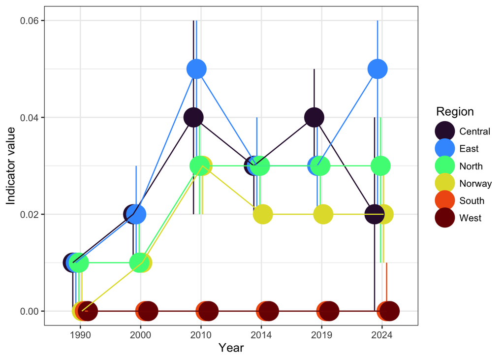

Figure 2: Indicator values for brown bear abundance by geographic region and nationally, with uncertainty bands from the resampled distribution.

```r
summary_out |>
  ggplot(aes(x = year, y = median, colour = part, group = part)) +
  geom_pointrange(
    aes(ymin = p_025, ymax = p_975),
    size = 2,
    position = position_dodge(width = 0.3)
  ) +
  geom_line(position = position_dodge(width = 0.3)) +
  theme_bw(base_size = 12) +
  labs(y = "Indicator value", x = "Year") +
  scale_colour_viridis_d(option = "turbo", name = "Region")
```

```r
summary_out |>
  unite(col = "CI_95", c(p_025, p_975), sep = " - ") |>
  unite(col = "IQR", c(p_25, p_75), sep = " - ") |>
  select(
    ECT,
    Indicator,
    ID,
    "Accounting area" = part,
    Ecosystem,
    "Closing year" = year,
    "Indicator value" = median,
    "95% CI" = CI_95,
    "50% CI" = IQR
  ) |>
  kable()
```

Table 2: Indicator values and uncertainty estimates for brown bear abundance.

| ECT | Indicator | ID | Accounting area | Ecosystem | Closing year | Indicator value | 95% CI | 50% CI |
| --- | --- | --- | --- | --- | --- | --- | --- | --- |
| B3 | Brown bear abundance | NO_BBAB_001 | Norway | Boreal/montane forests | 1990 | 0.00 | 0 - 0.01 | 0 - 0 |
| B3 | Brown bear abundance | NO_BBAB_001 | Norway | Boreal/montane forests | 2000 | 0.01 | 0.01 - 0.01 | 0.01 - 0.01 |
| B3 | Brown bear abundance | NO_BBAB_001 | Norway | Boreal/montane forests | 2010 | 0.03 | 0.02 - 0.03 | 0.02 - 0.03 |
| B3 | Brown bear abundance | NO_BBAB_001 | Norway | Boreal/montane forests | 2014 | 0.02 | 0.02 - 0.02 | 0.02 - 0.02 |
| B3 | Brown bear abundance | NO_BBAB_001 | Norway | Boreal/montane forests | 2019 | 0.02 | 0.02 - 0.02 | 0.02 - 0.02 |
| B3 | Brown bear abundance | NO_BBAB_001 | Norway | Boreal/montane forests | 2024 | 0.02 | 0.01 - 0.03 | 0.02 - 0.02 |
| B3 | Brown bear abundance | NO_BBAB_001 | Central | Boreal/montane forests | 1990 | 0.01 | 0 - 0.01 | 0 - 0.01 |
| B3 | Brown bear abundance | NO_BBAB_001 | Central | Boreal/montane forests | 2000 | 0.02 | 0.01 - 0.02 | 0.01 - 0.02 |
| B3 | Brown bear abundance | NO_BBAB_001 | Central | Boreal/montane forests | 2010 | 0.04 | 0.02 - 0.06 | 0.04 - 0.05 |
| B3 | Brown bear abundance | NO_BBAB_001 | Central | Boreal/montane forests | 2014 | 0.03 | 0.02 - 0.03 | 0.03 - 0.03 |
| B3 | Brown bear abundance | NO_BBAB_001 | Central | Boreal/montane forests | 2019 | 0.04 | 0.03 - 0.05 | 0.04 - 0.04 |
| B3 | Brown bear abundance | NO_BBAB_001 | Central | Boreal/montane forests | 2024 | 0.02 | 0 - 0.04 | 0.02 - 0.03 |
| B3 | Brown bear abundance | NO_BBAB_001 | East | Boreal/montane forests | 1990 | 0.01 | 0 - 0.01 | 0 - 0.01 |
| B3 | Brown bear abundance | NO_BBAB_001 | East | Boreal/montane forests | 2000 | 0.02 | 0.01 - 0.03 | 0.01 - 0.02 |
| B3 | Brown bear abundance | NO_BBAB_001 | East | Boreal/montane forests | 2010 | 0.05 | 0.03 - 0.06 | 0.04 - 0.05 |
| B3 | Brown bear abundance | NO_BBAB_001 | East | Boreal/montane forests | 2014 | 0.03 | 0.02 - 0.04 | 0.03 - 0.03 |
| B3 | Brown bear abundance | NO_BBAB_001 | East | Boreal/montane forests | 2019 | 0.03 | 0.02 - 0.04 | 0.03 - 0.03 |
| B3 | Brown bear abundance | NO_BBAB_001 | East | Boreal/montane forests | 2024 | 0.05 | 0.02 - 0.06 | 0.04 - 0.05 |
| B3 | Brown bear abundance | NO_BBAB_001 | North | Boreal/montane forests | 1990 | 0.01 | 0 - 0.01 | 0 - 0.01 |
| B3 | Brown bear abundance | NO_BBAB_001 | North | Boreal/montane forests | 2000 | 0.01 | 0.01 - 0.02 | 0.01 - 0.01 |
| B3 | Brown bear abundance | NO_BBAB_001 | North | Boreal/montane forests | 2010 | 0.03 | 0.02 - 0.04 | 0.02 - 0.03 |
| B3 | Brown bear abundance | NO_BBAB_001 | North | Boreal/montane forests | 2014 | 0.03 | 0.02 - 0.03 | 0.02 - 0.03 |
| B3 | Brown bear abundance | NO_BBAB_001 | North | Boreal/montane forests | 2019 | 0.03 | 0.02 - 0.03 | 0.02 - 0.03 |
| B3 | Brown bear abundance | NO_BBAB_001 | North | Boreal/montane forests | 2024 | 0.03 | 0.01 - 0.04 | 0.02 - 0.03 |
| B3 | Brown bear abundance | NO_BBAB_001 | South | Boreal/montane forests | 1990 | 0.00 | 0 - 0 | 0 - 0 |
| B3 | Brown bear abundance | NO_BBAB_001 | South | Boreal/montane forests | 2000 | 0.00 | 0 - 0 | 0 - 0 |
| B3 | Brown bear abundance | NO_BBAB_001 | South | Boreal/montane forests | 2010 | 0.00 | 0 - 0 | 0 - 0 |
| B3 | Brown bear abundance | NO_BBAB_001 | South | Boreal/montane forests | 2014 | 0.00 | 0 - 0 | 0 - 0 |
| B3 | Brown bear abundance | NO_BBAB_001 | South | Boreal/montane forests | 2019 | 0.00 | 0 - 0 | 0 - 0 |
| B3 | Brown bear abundance | NO_BBAB_001 | South | Boreal/montane forests | 2024 | 0.00 | 0 - 0.01 | 0 - 0 |
| B3 | Brown bear abundance | NO_BBAB_001 | West | Boreal/montane forests | 1990 | 0.00 | 0 - 0 | 0 - 0 |
| B3 | Brown bear abundance | NO_BBAB_001 | West | Boreal/montane forests | 2000 | 0.00 | 0 - 0 | 0 - 0 |
| B3 | Brown bear abundance | NO_BBAB_001 | West | Boreal/montane forests | 2010 | 0.00 | 0 - 0 | 0 - 0 |
| B3 | Brown bear abundance | NO_BBAB_001 | West | Boreal/montane forests | 2014 | 0.00 | 0 - 0 | 0 - 0 |
| B3 | Brown bear abundance | NO_BBAB_001 | West | Boreal/montane forests | 2019 | 0.00 | 0 - 0 | 0 - 0 |
| B3 | Brown bear abundance | NO_BBAB_001 | West | Boreal/montane forests | 2024 | 0.00 | 0 - 0 | 0 - 0 |

## 11. Export file

**Export resampled indicator draws**

```r
write.csv(out, here::here("data/results_NO_BBAB_001_v0.1.0.csv"), row.names = FALSE)
```

## 12. Author contributions

Not relevant, as this is the work of a single author. I would, however, like to acknowledge the work of those that created the indicator on *Naturindeks* (Norwegian Institute for Nature Research and partners 2025).

**TipSession Info**

This information is mainly aimed at developers that need to recreate the R environment that produced the html. Important note: this information is about the R session that was running when the html was rendered, and if some of the code chunks were not evaluated when the html was rendered, they may have been executed in a different environment.